# Introduction to gaptrace

## Overview

`gaptrace` acts as a **High-Contrast Executive Summary** tool, transforming tabular sustainability data collection trackers into decisive visual narratives. By strictly utilizing a “Maturity Grayscale” (Light Gray to Solid Black), it strips away the cognitive distraction of color, enabling leaders to immediately assess attainment density, flag critical stagnation, and identify true bottlenecks.

## 1. Load Dummy Data

The package includes a synthetic dataset named `sustain_dummy_data` representing ~50 rows of simulated environmental consulting data.

```r
library(gaptrace)

# View the first few rows
head(sustain_dummy_data)
```

```
#>   id_dato             descripcion
#> 1 DAT-001 Sustainability metric 1
#> 2 DAT-002 Sustainability metric 2
#> 3 DAT-003 Sustainability metric 3
#> 4 DAT-004 Sustainability metric 4
#> 5 DAT-005 Sustainability metric 5
#> 6 DAT-006 Sustainability metric 6
#>                                           tematicas        estatus
#> 1                                      Supply Chain      Validated
#> 2                                  Carbon Footprint Rough Estimate
#> 3               Energy Efficiency, Water Management Rough Estimate
#> 4               Carbon Footprint, Energy Efficiency Rough Estimate
#> 5 Energy Efficiency, Carbon Footprint, Supply Chain      Validated
#> 6               Energy Efficiency, Water Management Rough Estimate
#>     responsable   referencia unidades          etiquetas prioridad
#> 1   Diana Evans DocRef- 2224       m3         Facilities      Baja
#> 2   Bob Johnson DocRef- 6864       m3              Fleet      Baja
#> 3   Diana Evans DocRef- 2944    units Facilities, Urgent      Baja
#> 4   Alice Smith DocRef- 8682       kg Facilities, Urgent      Baja
#> 5 Charlie Davis DocRef- 5276   liters              Fleet     Media
#> 6 Charlie Davis DocRef- 9942   tonnes            Ops, HQ     Media
#>   fecha_captura
#> 1    2026-02-28
#> 2    2026-02-09
#> 3    2026-04-06
#> 4    2026-02-17
#> 5    2026-03-19
#> 6    2026-02-12
```

## 2. Ingest Data

We ingest the raw data using `sustain_ingest()`. This function automatically maps critical metadata like `date_captured` (`fecha_captura`) and `priority` (`prioridad`). When the `lang = "es"` argument is applied, it handles row-level translation for priority tiers (e.g., converting “Alta” into “High”), ensuring the English visual schema stays robust.

```r
tracker <- sustain_ingest(sustain_dummy_data, lang = "es")
class(tracker)
```

```
#> [1] "sustain_tracker" "tbl_df"          "tbl"             "data.frame"
```

## 3. Visualizing Maturity Foundation

To evaluate the attainment of the overall project, the package provides a **Stacked Loading Bar** approach. The solid monochromatic blocks intentionally distinguish the pending gray “foundation” from the black attained/validated data points, granting an immediate sense of baseline maturity.

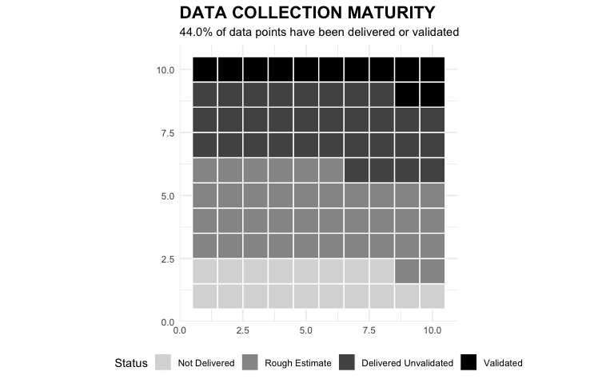

```r
plot_waffle_progress(tracker)
```

## 4. Identifying Bottlenecks & Critical Anchors

The interdependency network graph links specific data points to overarching themes. We utilize **Node Scaling**, where larger nodes represent “Critical Bottlenecks” (data points required by multiple themes), while **Black Diamonds** act as the primary thematic anchors.

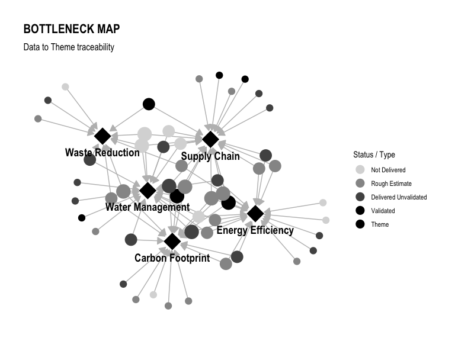

```r
# Generate a static network graph
plot_theme_network(tracker, interactive = FALSE)
```

*(Note: Use `interactive = TRUE` to render an interactive `visNetwork` graph in your local R environment.)*

## 5. Owner Performance Leaderboard

To drive accountability, we track owner efficiency through a 100% scaled leaderboard. It is ordered strictly by the percentage of data they have validated, revealing immediately which teams are leading in closure efficiency.

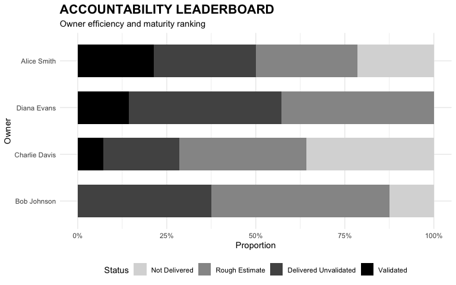

```r
plot_accountability(tracker)
```

## 6. Thematic Health Heatmap

By assigning an arbitrary row and column index to each item, we generate uniform “Maturity Blocks” per theme. This granular layout acts as a rapid health check across specific project areas, showing the exact density of completion.

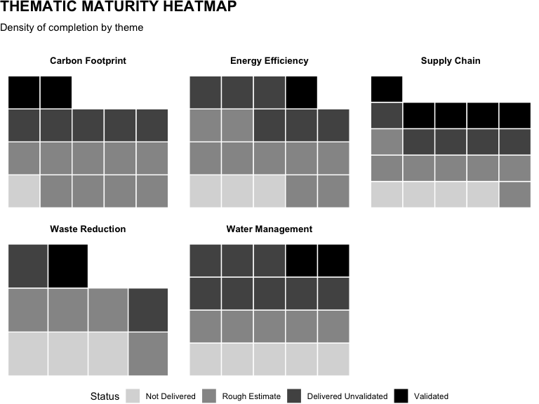

```r
plot_theme_heatmap(tracker)
```

## 7. Tracking Collection Velocity

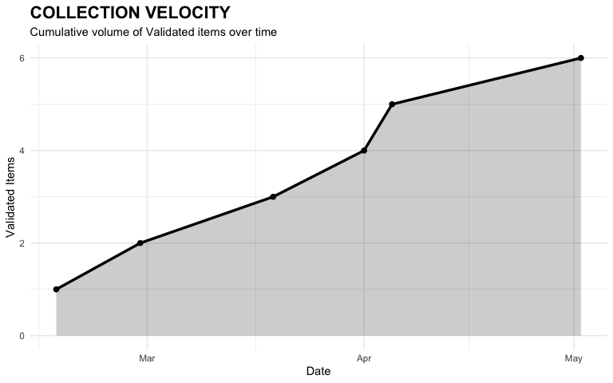

```r
plot_collection_trend(tracker)
```

## 8. Executive Triage: Priority Quadrant

Before handing off tasks to operational teams, it is crucial to map out red flags. The Priority Quadrant highlights exactly where attention is needed. Data points mapped as “High” priority and “Not Delivered” are given a stark solid Black highlight, immediately drawing executive attention.

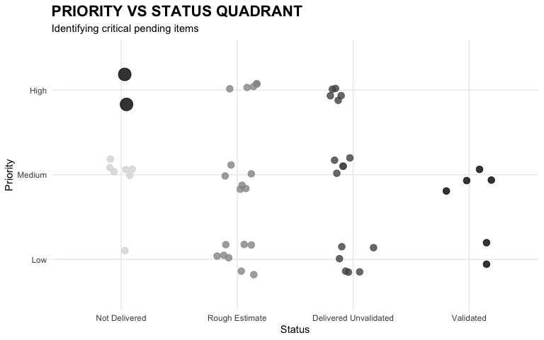

```r
plot_quadrant(tracker)
```

## 9. Operational Hand-off: Exporting Targeted Lists

Finally, directly informed by the “Stagnation Risks” and “Red Flags” identified above, managers can generate an actionable sheet for operational teams. By filtering strictly for pending gaps (`filter_status = c("Not Delivered")`), you hand off a precise target list.

```r
# Create an Excel file containing only 'Not Delivered' items
export_targeted_list(
  tracker,
  filter_status = c("Not Delivered"),
  file_path = "urgent_action_list.xlsx"
)
```